# R Notebook: Introduction to Strings

Kyle Rasku

References:

Wickham, C., Jeon, T. & Cotton, R. (2021). String Manipulation with stringr in R; DataCamp https://app.datacamp.com/learn/courses/string-manipulation-with-stringr-in-r

and

Wickham, H. & Grolemund, G. (2017) R for Data Science, O’Reilly and Associates **Freely accessible here:** https://r4ds.had.co.nz/index.html

```r
library(tidyverse)
```

PART 1 Creating and Joining Strings Dealing with Quotes and Single Quotes within a String

```r
# You can begin and end with either single or double quotes

String1 <- "This is a string"
String2 <- 'Another "awesome" string!'

# If you choose to use double or single quotes within a string delimited by that character,
# you need to use the backslash, \, to escape the internal instance of the character

String3 <- "The title is \"Escape Quotes from Alcatraz\""
String4 <- "He said, 'Nobody knows the trouble I\'ve seen!'"

# Just so you know, to type an actual backslash, you need 2 backslashes

String5 <- "The path to my file is C:\\Stuff\\Nerdy"

# Use the 'writeLines' function to see what things will look like
# writeLines is the stringr version of base R's paste and paste0

writeLines(String1)
```

```
This is a string
```

```r
writeLines(String2)
```

```
Another "awesome" string!
```

```r
writeLines(String3)
```

```
The title is "Escape Quotes from Alcatraz"
```

```r
writeLines(String4)
```

```
He said, 'Nobody knows the trouble I've seen!'
```

```r
writeLines(String5)
```

```
The path to my file is C:\Stuff\Nerdy
```

PART 2 Joining Strings with Base R’s paste and paste0

```r
# The paste function takes a series of strings and puts them together in to a single string
# By default, the new string will separate each vector item with a space
# By using the optional sep argument, you can specify the character that will separate the vector items

paste("a", "e", "i", "o", "u", "y")
```

```
[1] "a e i o u y"
```

```r
paste("The English vowels are", " a", "e", "i", "o", "u", "and y", sep = ",")
```

```
[1] "The English vowels are, a,e,i,o,u,and y"
```

```r
# paste, paste0 and str_c: comparing behavior

nyc <- c("New York", "Big Apple", "Broadway")
la <- c("Los Angeles", "Tinseltown", "Hollywood")
paste(nyc, la, sep = ", ")
```

```
[1] "New York, Los Angeles" "Big Apple, Tinseltown" "Broadway, Hollywood"
```

```r
paste0(nyc, la)
```

```
[1] "New YorkLos Angeles" "Big AppleTinseltown" "BroadwayHollywood"
```

```r
str_c(nyc, "=", la, collapse="; ")
```

```
[1] "New York=Los Angeles; Big Apple=Tinseltown; Broadway=Hollywood"
```

```r
# Combining paste commands to create more complex output

teachers <- c("Dr. Moody", "Dr. Barnes", "Dr. Mittal", "Dr. Jiminez")
courses <- c("Introduction to Anatomy", "Biochemistry", "Microbiology", "Fundamentals of Medicine")
locations <- c("Hewitt 2431", "Ogilvy 45", "Ogilvy 58", "Hewitt 881")

paste(teachers, "will be your instructor for", courses, "at", locations)
```

```
[1] "Dr. Moody will be your instructor for Introduction to Anatomy at Hewitt 2431"
[2] "Dr. Barnes will be your instructor for Biochemistry at Ogilvy 45"
[3] "Dr. Mittal will be your instructor for Microbiology at Ogilvy 58"
[4] "Dr. Jiminez will be your instructor for Fundamentals of Medicine at Hewitt 881"
```

```r
# blank line
writeLines("")
```

```r
# or assign output vectors to a variable, to create a single output with writeLines:
schedule <- paste(teachers, "will be your instructor for", courses, "at", locations)
writeLines(schedule)
```

```
Dr. Moody will be your instructor for Introduction to Anatomy at Hewitt 2431
Dr. Barnes will be your instructor for Biochemistry at Ogilvy 45
Dr. Mittal will be your instructor for Microbiology at Ogilvy 58
Dr. Jiminez will be your instructor for Fundamentals of Medicine at Hewitt 881
```

```r
action <- "go"

paste("Going to a",
      paste(rep(action, 2), collapse = "-"),
      collapse = " ")
```

```
[1] "Going to a go-go"
```

```r
nonsense_word <- "tu"

paste("Put two in your",
      paste(rep(nonsense_word, 2), collapse = "-"),
      collapse = " ")
```

```
[1] "Put two in your tu-tu"
```

PART 3 Counting the number of code points in a string

```r
# Returns the number of code points in a string

str_length("The quick brown fox jumps over the lazy dog.")
```

```
[1] 44
```

```r
str_length(c("String One", "String Two Fish", "Red Fish, Blue Fish"))
```

```
[1] 10 15 19
```

PART 4 Combining Strings with str_c

```r
prefix <- "It was a dark and stormy "

str_c(prefix, "night.")
```

```
[1] "It was a dark and stormy night."
```

```r
str_c(prefix, "boat ride.")
```

```
[1] "It was a dark and stormy boat ride."
```

```r
str_c(prefix, "drink.")
```

```
[1] "It was a dark and stormy drink."
```

```r
# Using the sep argument to control how strings are separated

str_c("123456", "11/15/2021", "Digestive Health Exam", "92.2", "Pass", "97", sep = ";")
```

```
[1] "123456;11/15/2021;Digestive Health Exam;92.2;Pass;97"
```

```r
# Display missing values as NA with str_replace_na

record <- c(567322, "12/27/21", "Johnson, George A.", NA, "Spring 2022", "3.55")
str_replace_na(record)
```

```
[1] "567322"             "12/27/21"           "Johnson, George A." "NA"                 "Spring 2022"        "3.55"
```

```r
# Auto-vectorization with str_c

students <- str_c("Student ", c("125542", "126781", "124872"), " Academic Year ", c("2020-21", "2020-21", "2021-22"))
writeLines(students)
```

```
Student 125542 Academic Year 2020-21
Student 126781 Academic Year 2020-21
Student 124872 Academic Year 2021-22
```

```r
# Using an if statement with str_c

name <- "Dr. Amy Pace"
course <- "Introduction to Pediatrics"
course2 <- TRUE

str_c(
  "Your instructor will be ", name, " for ", course,
  if (course2) ", and the following clinical rotation",
  "."
)
```

```
[1] "Your instructor will be Dr. Amy Pace for Introduction to Pediatrics, and the following clinical rotation."
```

```r
# Using str_c with collapse
# NOTE: passing a variable name to the 'parse' command turns the name into a variable object that can
# then be referenced / evaluated with the 'eval' command.  This is very handy for creating concise code!

name1 <- c("Jodie", "A", "Pierce")
name2 <- c("Chantell", "B", "Richards")
name3 <- c("Eric", "J", "Johnson")
name4 <- c("Anna", "R", "Yurchenko")

for (x in 1:4) {
  variable <- str_c("name", x)
  print(str_c(eval(parse(text = variable)) , collapse = " "))
}
```

```
[1] "Jodie A Pierce"
[1] "Chantell B Richards"
[1] "Eric J Johnson"
[1] "Anna R Yurchenko"
```

PART 5 Sub-setting strings with str_sub

```r
# Sub-setting strings with str_sub

courses <- c("FMS501", "FMS511", "LMH513")
prefixes <- str_sub(courses, 1, 3)
writeLines(prefixes)
```

```
FMS
FMS
LMH
```

```r
# negative numbers count backwards from end
str_sub(courses, -3, -1)
```

```
[1] "501" "511" "513"
```

```r
# Using str_sub to perform transformation

scale_values <- c("Disagree", "Neutral", "Agree")
str_sub(scale_values, 1, 1) <- str_to_lower(str_sub(scale_values, 1, 1))
print(scale_values)
```

```
[1] "disagree" "neutral"  "agree"
```

PART 6 Finding Patterns in Strings with str_starts and str_ends

```r
places <- c("New York City", "Jefferson City", "Charlotte Amalie", "Honolulu", "Montpelier", "Pago Pago")
str_starts(places, "[ABCDEFGHIJ]")
```

```
[1] FALSE  TRUE  TRUE  TRUE FALSE FALSE
```

```r
str_ends(places, "City")
```

```
[1]  TRUE  TRUE FALSE FALSE FALSE FALSE
```

```r
str_ends(places, "City", negate=TRUE)
```

```
[1] FALSE FALSE  TRUE  TRUE  TRUE  TRUE
```

```r
places[str_starts(places, "[ABCDEFGHIJ]")]
```

```
[1] "Jefferson City"   "Charlotte Amalie" "Honolulu"
```

PART 7 More on Pattern Matching with Strings

```r
# Using str_detect to find a pattern in a string or vector of strings
string_vector <- c("alibi", "dizzy", "launch", "hazardous", "epiphany", "alliteration", "demotic", "mellifluous")
contains_z <- str_detect(string_vector, pattern = fixed("z"))

print(contains_z)
```

```
[1] FALSE  TRUE FALSE  TRUE FALSE FALSE FALSE FALSE
```

```r
sum(contains_z)
```

```
[1] 2
```

```r
string_vector[contains_z]
```

```
[1] "dizzy"     "hazardous"
```

```r
# str_subset allows you to subset strings based on a match
# the match can be a fixed match (as below), a regular expression, or rebus expression
# the regular expression below matches any character in the brackets [], exactly {2} times
# the matched words returned below all have two consecutive vowels somewhere in the word
# for more on using regular expressions, visit https://www.regular-expressions.info/tutorial.html

str_subset(string_vector, '[aeiouy]{2}')
```

```
[1] "launch"       "hazardous"    "alliteration" "mellifluous"
```

```r
str_subset(string_vector, '[aeiouy]{3}')
```

```
[1] "mellifluous"
```

```r
# Using str_count with string_vector

writeLines(string_vector)
```

```
alibi
dizzy
launch
hazardous
epiphany
alliteration
demotic
mellifluous
```

```r
counts <- str_count(string_vector, 'z')
counts
```

```
[1] 0 2 0 1 0 0 0 0
```

```r
sum(counts)
```

```
[1] 3
```

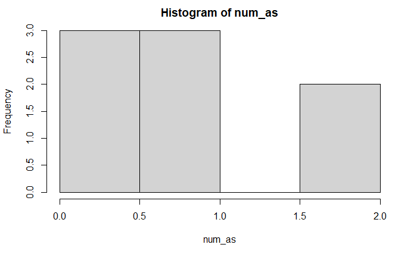

```r
# Using str_count with a pattern to create a list of counts

num_as <- str_count(string_vector, pattern = fixed("a"))
hist(num_as)
```

```r
# Using a boolean expression to subset a string vector

string_vector[num_as>1]
```

```
[1] "hazardous"    "alliteration"
```

PART 8 Splitting Strings

```r
# Splitting strings

sentence <- "The course was taught last semester by Dr. Joe Amonsoovic.  He really was the greatest!"


str_split(sentence, " ", simplify = TRUE)
```

```
     [,1]  [,2]     [,3]  [,4]     [,5]   [,6]       [,7] [,8]  [,9]  [,10]         [,11] [,12] [,13]    [,14] [,15] [,16]
[1,] "The" "course" "was" "taught" "last" "semester" "by" "Dr." "Joe" "Amonsoovic." ""    "He"  "really" "was" "the" "greatest!"
```

```r
words_from_sentence <- str_split(sentence, " ", simplify = TRUE)
instructor <- paste(words_from_sentence[1,9:10], collapse = " ")
instructor
```

```
[1] "Joe Amonsoovic."
```

```r
# Use two-backslashes to escape the literal character, .
# Otherwise, R assumes you mean 'regular expression dot' which matches any character
instructor <- str_remove(instructor, "\\.")

writeLines(instructor)
```

```
Joe Amonsoovic
```

```r
# Splitting strings

chipmunks <- "Alvin & Simon & Theodore & Sabrina"


str_split(chipmunks, pattern = " & ")
```

```
[[1]]
[1] "Alvin"    "Simon"    "Theodore" "Sabrina"
```

```r
str_split(chipmunks, pattern = " & ", n = 3)
```

```
[[1]]
[1] "Alvin"              "Simon"              "Theodore & Sabrina"
```

```r
# Splitting a list into a matrix using the simplify = TRUE argument

names <- c("Smith, Archie", "Tuttle, Jane", "Yuskitas, Anne")
mNames <- str_split(names, fixed(", "), simplify = TRUE)
first_names <- mNames[,2]
last_names <- mNames[,1]

mNames
```

```
     [,1]       [,2]
[1,] "Smith"    "Archie"
[2,] "Tuttle"   "Jane"
[3,] "Yuskitas" "Anne"
```

```r
writeLines("\n")
```

```r
first_names
```

```
[1] "Archie" "Jane"   "Anne"
```

```r
last_names
```

```
[1] "Smith"    "Tuttle"   "Yuskitas"
```

PART 9 WORKING WITH POE LINES

```r
# Developing and executing a simple algorithm to find interesting words in a corpus

poe_lines <- '"Seldom we find," says Solomon Don Dunce, "Half an idea in the profoundest sonnet. Through all the flimsy things we see at once As easily as through a Naples bonnet- Trash of all trash!- how can a lady don it? Yet heavier far than your Petrarchan stuff- Owl-downy nonsense that the faintest puff Twirls into trunk-paper the while you con it."'

# remove punctuation (as you may have guessed, both ? and . are special to regular expressions and must be escaped!)
poe_lines <- str_replace_all(poe_lines, '[,"\\?\\.!]', '')

# obtain a lower-case vector
words <- str_to_lower(str_split(poe_lines, " ", simplify = TRUE))

# remove end-of-word dashes (a dash also has a special regex meaning, so it too is escaped; the $ anchors the dash
# to the end of the word, so that only dashes that appear at the end of a word will be removed.)
words <- str_remove(words, "\\-$")

# remove duplicates
words <- words[!duplicated(words)]

# of chars per word
word_lengths <- str_length(words)

# average word-length
avg_word_length <- mean(word_lengths)

# use the vector of lengths to create a boolean indexing vector to get all the words that are longer than average
interesting_words <- words[word_lengths>avg_word_length]

interesting_words
```

```
 [1] "seldom"      "solomon"     "dunce"       "profoundest" "sonnet"      "through"     "flimsy"      "things"      "easily"
[10] "naples"      "bonnet"      "trash"       "heavier"     "petrarchan"  "stuff"       "owl-downy"   "nonsense"    "faintest"
[19] "twirls"      "trunk-paper" "while"
```

PART 9 Replacing Parts of Strings

```r
# Replace one or more instances of a pattern with something else

str_replace(string_vector, '[aeiouy]', '?')
```

```
[1] "?libi"        "d?zzy"        "l?unch"       "h?zardous"    "?piphany"     "?lliteration" "d?motic"      "m?llifluous"
```

```r
str_replace_all(string_vector, '[aeiouy]', '?')
```

```
[1] "?l?b?"        "d?zz?"        "l??nch"       "h?z?rd??s"    "?p?ph?n?"     "?ll?t?r?t??n" "d?m?t?c"      "m?ll?fl???s"
```

```r
# Another example, replacing & with 'and'

str_replace("Tom & Jerry", pattern = " & ", replacement = " and ")
```

```
[1] "Tom and Jerry"
```

```r
str_replace_all("Alvin & Simon & Theodore", pattern = " & ", replacement = " and ")
```

```
[1] "Alvin and Simon and Theodore"
```

PART 10 Introducing rebus and dplyr

```r
# babynames is a data set of babynames
# rebus is a library for pattern-matching
# https://www.rdocumentation.org/packages/rebus/versions/0.1-3


library("rebus")
library("babynames")
```

In this section, we will introduce a little bit of dplyr, just to do some filtering of data that we will then operate on with stringr functions. Below, dplyr is used to *filter* the babynames data by year.

If you compare the R cell below with the cell following it, you will notice that there’s more than one way to use dplyr. You can make the dataframe you wish to operate on the first argument to the function as in:

filter(babynames, year==2014)

OR you can use the **pipe operator** to ‘pipe’ the data frame to the filter function, like this:

babynames %>% filter(year==2014)

These look different, but they do the same thing. And, of course, you can assign the results to a variable that you can then reference.

babies_of_2014 <- filter(babynames, year==2014)

OR

babies_of_2014 <- babynames %>% filter(year==2014)

```r
babies_2014 <- filter(babynames, year==2014)
names_2014 <- babies_2014$name

# Create a list of the last two letters of every name
last_two <- str_sub(names_2014, -2, -1)

# Create a boolean vector, telling whether or not a name ends in 'ee'
ends_in_ee <- str_detect(last_two, pattern = fixed("ee"))

# Subset data frame using boolean vector as a filter
sex <- babies_2014[ends_in_ee,]$sex

# Basic table
table(sex)
```

```
sex
  F   M
572  84
```

In 2014, many more commonly female names ended in ‘ee’ than commonly male names.

```r
# Percentage of 2014 boys names that contain "q"
boys_2014 <- babynames %>% filter(sex=="M", year==2014)
boys_names <- boys_2014$name
with_q <- str_detect(boys_names, pattern = "q" %R% ANY_CHAR)
mean(with_q)*100
```

```
[1] 0.6834199
```

Let’s see the names:

```r
boys_2014[with_q,]$name
```

```
 [1] "Joaquin"     "Enrique"     "Ezequiel"    "Marquis"     "Dominique"   "Jaquan"      "Marquise"    "Marquez"     "Marques"
[10] "Daquan"      "Jacques"     "Shaquille"   "Dequan"      "Marquan"     "Marquel"     "Tyquan"      "Luqman"      "Jayquan"
[19] "Jaquez"      "Malique"     "Juaquin"     "Laquan"      "Roque"       "Pasquale"    "Yaqub"       "Marquell"    "Raquan"
[28] "Tyrique"     "Miqueas"     "Domonique"   "Esequiel"    "Marquese"    "Aquiles"     "Jacque"      "Jaquavion"   "Unique"
[37] "Shaquan"     "Dominque"    "Jacquez"     "Marque"      "Henrique"    "Marquice"    "Rayquan"     "Sequoia"     "Marqus"
[46] "Miquel"      "Naquan"      "Aqib"        "Daequan"     "Aqeel"       "Daiquan"     "Jaquarius"   "Joaquim"     "Rodriquez"
[55] "Saquan"      "Taquan"      "Tyquez"      "Zyquan"      "Drequan"     "Luqmaan"     "Marquee"     "Zaquan"      "Abdiqani"
[64] "Anquan"      "Jaquon"      "Aaqil"       "Aquarius"    "Jaques"      "Tayquan"     "Trequan"     "Aquil"       "Dequincy"
[73] "Enrrique"    "Jacquan"     "Jahquan"     "Jaiquan"     "Jaquann"     "Lequan"      "Luisenrique" "Marquies"    "Yaqoob"
[82] "Aquinas"     "Demarquis"   "Diquan"      "Equan"       "Jamarques"   "Jaquae"      "Jquan"       "Laquinton"   "Marquavious"
[91] "Marquavis"   "Marquelle"   "Melquisedec" "Tarquin"     "Yacqub"      "Zayquan"
```

Those are some nifty names!

CAPTURE AND GROUP

```r
# capture is good with match functions
rx_price <- capture(digit(1, Inf) %R% DOT %R% digit(2))
rx_quantity <- capture(digit(1, Inf))
rx_all <- DOLLAR %R% rx_price %R% " for " %R% rx_quantity

str_match("The price was $123.99 for 12.", rx_price)
```

```
     [,1]     [,2]
[1,] "123.99" "123.99"
```

```r
str_match_all("The price was $123.99 for 12.", rx_quantity)
```

```
[[1]]
     [,1]  [,2]
[1,] "123" "123"
[2,] "99"  "99"
[3,] "12"  "12"
```

```r
str_match_all("The price was $123.99 for 12.", rx_all)
```

```
[[1]]
     [,1]             [,2]     [,3]
[1,] "$123.99 for 12" "123.99" "12"
```

```r
# group is mostly used with alternation.  See ?or.
rx_spread <- group("peanut butter" %|% "jam" %|% "marmalade")
str_match_all(
  "You can have peanut butter, jam, or marmalade on your toast.",
  rx_spread
)
```

```
[[1]]
     [,1]
[1,] "peanut butter"
[2,] "jam"
[3,] "marmalade"
```

```r
# Capturing an email address with rebus

contact_list <- c("jaime1@lannister.com", "ned.stark@winterfell.org", "betrayalcentral@targerian.com")

email <- capture(one_or_more(WRD)) %R% "@" %R% capture(one_or_more(WRD)) %R% DOT %R% capture(one_or_more(WRD))
email_parts <- str_match(contact_list, email)

email_parts
```

```
     [,1]                            [,2]              [,3]         [,4]
[1,] "jaime1@lannister.com"          "jaime1"          "lannister"  "com"
[2,] "stark@winterfell.org"          "stark"           "winterfell" "org"
[3,] "betrayalcentral@targerian.com" "betrayalcentral" "targerian"  "com"
```

```r
writeLines("")
```

```r
email_parts[,3]
```

```
[1] "lannister"  "winterfell" "targerian"
```

```r
# Rebus backreferences

narratives <- c("SKIING", "SURFING", "CLEANING", "BUILDING", "BOOGIEING", "DIVORCED")
pattern <- capture(one_or_more(WRD)) %R% "ING"

# Visualize the capture groups
str_view(narratives, pattern)
```

[interactive chart not shown]

```r
# Change the phrases using the captured words
str_replace(narratives, pattern, str_c("CARELESSLY", REF1, sep = " "))
```

```
[1] "CARELESSLY SKI"    "CARELESSLY SURF"   "CARELESSLY CLEAN"  "CARELESSLY BUILD"  "CARELESSLY BOOGIE" "DIVORCED"
```

PART 11 Formatting Numbers

```r
# Formatting numbers with stringr and paste

# Some vectors of numbers
percent_change  <- c(4, -1.91, 3.00, -5.002)
income <-  c(72.19, 1030.18, 10291.93, 1189192.18)
whole_income <- c("72", "1,030", "10,292", "1,189,192")
p_values <- c(0.12, 0.98, 0.0000191, 0.00000000002)

# Format c(0.0011, 0.011, 1) with digits = 1
format(c(0.0011, 0.011, 1), digits = 1)
```

```
[1] "0.001" "0.011" "1.000"
```

```r
# Format c(1.0011, 2.011, 1) with digits = 1
format(c(1.0011, 2.011, 1), digits = 1)
```

```
[1] "1" "2" "1"
```

```r
# Format percent_change to one place after the decimal point
str_c(format(percent_change, digits=2), "%")
```

```
[1] " 4.0%" "-1.9%" " 3.0%" "-5.0%"
```

```r
# Format income strings with $s
paste("$", whole_income, sep = "")
```

```
[1] "$72"        "$1,030"     "$10,292"    "$1,189,192"
```

```r
# Format p_values in fixed format
format(p_values, scientific = FALSE)
```

```
[1] "0.12000000000" "0.98000000000" "0.00001910000" "0.00000000002"
```

```r
# In scientific format
format(p_values, scientific = TRUE)
```

```
[1] "1.20e-01" "9.80e-01" "1.91e-05" "2.00e-11"
```

PART 12 Creating a simple table with format and paste

```r
# Define the column names
column_names <- c("Year 0", "Year 1", "Year 2", "Project Lifetime")

# Create formatted income
income <- c(72.19, 1030.18, 10291.93, 1189192.18)
formatted_income <- format(income, digits = 2, big.mark = ",")

# Create dollar_income
dollar_income <- paste0("$", formatted_income)

# Format the column names
formatted_names <- format(column_names, justify = "right")

# Create rows
rows <- paste(formatted_names, dollar_income, sep = "   ")

# Write rows
writeLines(rows)
```

```
          Year 0   $       72
          Year 1   $    1,030
          Year 2   $   10,292
Project Lifetime   $1,189,192
```